# Assessing Strong Parallel Trends via Close Comparison Groups

Session 2

Brantly Callaway

brantly.callaway@uga.edu

University of Georgia

September 18, 2026

## Introduction

$\newcommand{\E}{\mathbb{E}} \newcommand{\var}{\mathrm{var}} \newcommand{\cov}{\mathrm{cov}} \newcommand{\Var}{\mathrm{var}} \newcommand{\Cov}{\mathrm{cov}} \newcommand{\Corr}{\mathrm{corr}} \newcommand{\corr}{\mathrm{corr}} \newcommand{\L}{\mathrm{L}} \renewcommand{\P}{\mathrm{P}} \newcommand{\independent}{{\perp\!\!\!\perp}} \newcommand{\indicator}[1]{ \mathbf{1}\{#1\} } \newcommand{\ATT}{\text{ATT}} \newcommand{\ACR}{\text{ACR}}$Session 1: interpreting comparisons across doses as causal effects required strong parallel trends — a substantially stronger assumption than most researchers realize they are invoking

- We discussed some (sub-)cases where it might be plausible and/or weakened, but it seemed fundamentally difficult to assess as only untreated potential outcomes are observed in pre-treatment periods

This session: can we use pre-treatment data to say anything about whether (local) strong parallel trends is plausible in a given application?

- Main idea: check for close comparison groups — neighboring dose groups that have the same level of outcomes in pre-treatment periods, argue that strong parallel trends is more plausible for these groups

## Plan for This Session

1. Setup and discussion of strong parallel trends
2. Close comparison groups
3. Empirical application

# 1. Setup and Discussion of Strong Parallel Trends

## Setup

Same pre-post research design with a continuous treatment as Session 1:

- Two periods $t=1,2$;
- No one treated at $t=1$;
- Continuous dose $D_i$ realized at $t=2$

In order to make the argument that the levels of pre-treatment outcomes are informative about strong parallel trends, we need to think some more about where parallel trends and strong parallel trends come from. →

## Motivating Parallel Trends

The most common way to “more primitively” motivate the parallel trends assumption is as a combination of the following two assumptions (Ashenfelter and Card 1985; Angrist and Krueger 1999; Ghanem, Sant’Anna, and Wüthrich 2024; Marx, Tamer, and Tang 2025):

**Latent Unconfoundedness**

$$\big( Y_{it=1}(0), Y_{it=2}(0) \big) \;\independent\; D_i \;\mid\; \eta_i$$

where $\eta_i$ is time-invariant unobserved heterogeneity (i.e., a unit fixed effect)

- Unconfoundedness - because this corresponds to the type of unconfoundedness that is very common for observational causal inference
- Latent - because the confounder is unobserved

## Motivating Parallel Trends

The most common way to “more primitively” motivate the parallel trends assumption is as a combination of the following two assumptions (Ashenfelter and Card 1985; Angrist and Krueger 1999; Ghanem, Sant’Anna, and Wüthrich 2024; Marx, Tamer, and Tang 2025):

**Latent Unconfoundedness**

$$\big( Y_{it=1}(0), Y_{it=2}(0) \big) \;\independent\; D_i \;\mid\; \eta_i$$

where $\eta_i$ is time-invariant unobserved heterogeneity (i.e., a unit fixed effect)

- Latent unconfoundedness says that we could recover $\ATT(d \mid d)$ if we could find units in dose group $d$ and untreated units with the same $\eta_i$ and compare their outcomes
- The previous comparison is infeasible, though, because $\eta_i$ is unobserved

## Motivating Parallel Trends

The most common way to “more primitively” motivate the parallel trends assumption is as a combination of the following two assumptions (Ashenfelter and Card 1985; Angrist and Krueger 1999; Ghanem, Sant’Anna, and Wüthrich 2024; Marx, Tamer, and Tang 2025):

**Latent Unconfoundedness**

$$\big( Y_{it=1}(0), Y_{it=2}(0) \big) \;\independent\; D_i \;\mid\; \eta_i$$

where $\eta_i$ is time-invariant unobserved heterogeneity (i.e., a unit fixed effect)

- Alternatively, you can view this as “selection into being treated on time-invariant unobservables”:
  $$\indicator{D_i > 0} = m_0(\eta_i) + u_{it} \text{ with } u_{it} \independent \big(Y_{it=1}(0), Y_{it=2}(0)\big) \bigm| \eta_i$$
- No restrictions on selection into a particular dose at all

## Motivating Parallel Trends

The most common way to “more primitively” motivate the parallel trends assumption is as a combination of the following two assumptions (Ashenfelter and Card 1985; Angrist and Krueger 1999; Ghanem, Sant’Anna, and Wüthrich 2024; Marx, Tamer, and Tang 2025):

**Linear Model for Untreated Potential Outcomes**

$$Y_{it}(0) = \theta_t + \eta_i + e_{it}$$

- Under linearity of untreated potential outcomes, difference out $\eta_i$ and then parallel trends holds immediately by latent unconfoundedness
- However, these assumptions do not imply strong parallel trends—notice that the assumptions do not restrict potential outcomes $Y_{it=2}(d)$ for $d>0$ at all.

## Motivating Strong Parallel Trends

We can extend the notion of latent unconfoundedness as follows:

**Latent Unconfoundedness for Dose**

$$\big\{Y_{i,t=1}(0),\, Y_{i,t=2}(d) : d \in \mathcal{D}\big\} \;\independent\; D_i \;\mid\; \eta_i$$

- Extends latent unconfoundedness to holds for all potential outcomes, not just untreated ones
- Up to $\eta_i$ being unobserved, it is exactly the same assumption that you would see in the literature on continous treatment and dose response functions (Hirano and Imbens 2004)
- If $\eta_i$ were observed, we could compare units with the same $\eta_i$ but different doses to recover $\ATT(d)$

## Motivating Strong Parallel Trends

We can extend the notion of latent unconfoundedness as follows:

**Latent Unconfoundedness for Dose**

$$\big\{Y_{i,t=1}(0),\, Y_{i,t=2}(d) : d \in \mathcal{D}\big\} \;\independent\; D_i \;\mid\; \eta_i$$

- “Selection into dose on time-invariant unobservables”:
  $$D_i = m(\eta_i) + v_{it} \text{ with } v_{it} \independent \big(Y_{it=1}(0), Y_{it=2}(d) \big) \bigm| \eta_i$$
- Distribution of $\eta_i$ can systematically vary across dose groups, but other unobservables that affect potential outcomes cannot vary systematically across dose groups

## Motivating Strong Parallel Trends

We can also consider linear models for all potential outcomes:

**Linear Model for Potential Outcomes**

$$Y_{i,t}(d) = \theta_{t,d} + \beta_{t,d} \,\eta_i + e_{i,t}(d)$$

- Additive separability for parallel trends
- Coefficient on $\eta_i$ can vary with $t$ and/or $d$
- No tricks—this is exactly the same setup we would have in a linear model for potential outcomes if $\eta_i$ were observed

## School Closures Example

Back to Session 1’s running example where $dose$ = length of Covid school closure, $outcome$ = test scores

- $\eta_i$: school’s unobserved student ability
- $\theta_{t=2,d}$: the ability-neutral part of the dose response, e.g., the component of lost instructional time/disruption that hits *any* school closed for length $d$, regardless of its students’ baseline ability
- $\beta_{t=2,d}$: how strongly baseline ability $\eta_i$ translates into test scores, *given* closure length $d$ — i.e., varies with $d$ if high ability schools respond differently to different lengths of closures than low ability schools
  - Would be increasing in $d$ if high ability schools are more resilient to long closures than low ability schools.

## Does Strong Parallel Trends Hold in This Model?

Applying the same argument as in Session 1:
$$\begin{aligned}
\E[\Delta Y \mid D=d_h] - \E[\Delta Y \mid D=d_l] &= \ATT(d_h|d_h) - \ATT(d_l|d_l) \\
&= \underbrace{(\theta_{t=2,d_h} - \theta_{t=2,d_l}) + (\beta_{t=2,d_h} - \beta_{t=2,d_l}) \E[\eta \mid D=d_h]}_{\textrm{Causal Response}} \\
&+ \underbrace{\beta_{t=2,d_l} \Big( \E[\eta \mid D=d_h] - \E[\eta \mid D=d_l] \Big)}_{\textrm{Selection Bias}}
\end{aligned}$$

- We would like for the selection bias term to be equal to 0.
- In particular, we will consider looking for dose groups where there is no selection (on the time-invariant unobservables) into the dose (i.e., $\E[\eta \mid D=d_h] - \E[\eta \mid D=d_l] = 0$).

# 2. Close Comparison Groups

## Background

In Callaway, Dyal, Sant’Anna, and Tsyawo (2025), we introduce a notion of “close comparison groups”

- Setting of that paper: binary treatment, multiple pre-treatment periods, multiple comparison groups, looking for a way to relax the parallel trends assumption, and we look for pockets of simple identification
- Groups that are “alike” in terms of pre-treatment levels of outcomes are “close comparison groups”
- If you can find such groups, you can get very robust identification of causal effects (i.e., robustness to the identification strategy)

## CCGs Adapted to a Continuous Treatment Setting

The idea here is that, if we can find range(s) of dose groups that are close comparison groups for each other (i.e., have the same pre-treatment level of outcomes), then it will suggest that strong parallel trends holds (locally) for those dose groups.

## Close Comparsion Dose Groups

Suppose we two dose groups $d_h$ and $d_l$ that have the same pre-treatment levels of outcomes,
$$\E[Y_{t=1} \mid D=d_h] = \E[Y_{t=1} \mid D=d_l]$$

Then,

$$\begin{aligned}
\E[Y_{t=1} \mid D=d_h] &= \E[Y_{t=1}(0) \mid D=d_h] = \theta_1 + \E[\eta \mid D=d_h]
\end{aligned}$$

## Close Comparsion Dose Groups

Suppose we two dose groups $d_h$ and $d_l$ that have the same pre-treatment levels of outcomes,
$$\E[Y_{t=1} \mid D=d_h] = \E[Y_{t=1} \mid D=d_l]$$

Then,

$$\begin{aligned}
\E[Y_{t=1} \mid D=d_h] &= \E[Y_{t=1}(0) \mid D=d_h] = \theta_1 + \E[\eta \mid D=d_h]\\
\E[Y_{t=1} \mid D=d_l] &= \E[Y_{t=1}(0) \mid D=d_l] = \theta_1 + \E[\eta \mid D=d_l]
\end{aligned}$$

Thus, close comparison dose groups satisfy:

$$\E[Y_{t=1} \mid D=l] = \E[Y_{t=1} \mid D=d] \quad\iff\quad \E[\eta \mid D=l] = \E[\eta \mid D=d]$$

## Implications

In a similar fashion to using pre-treatment periods to validate the parallel trends assumption, we can use pre-treatment periods to validate the “no selection”

- We can do this globally,
- Find regions where the pre-treatment mean is flat, or
- Find regions where the pre-treatment mean is flat conditional on covariates

It rationalizes interpreting those regions as being regions where strong parallel trends is plausible, and suggests that we can recover locally comparable causal effects in those regions, e.g., $\ACR(d)$ in these regions.

# 3. Empirical Illustration

## Results

1. Post-treatment $\ATT(d|d)$
2. Post-treatment $\ACR(d)$
3. Pre-treatment $\ATT(d|d)$
4. Pre-test for same pre-treatment levels of outcomes
5. Post-treatment $\ACR(d)$ in close comparison region

## Results: ATT(d|d)

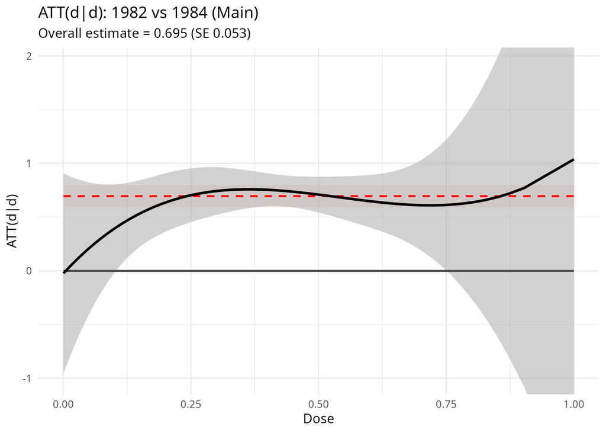

## Results: ATT(d|d)

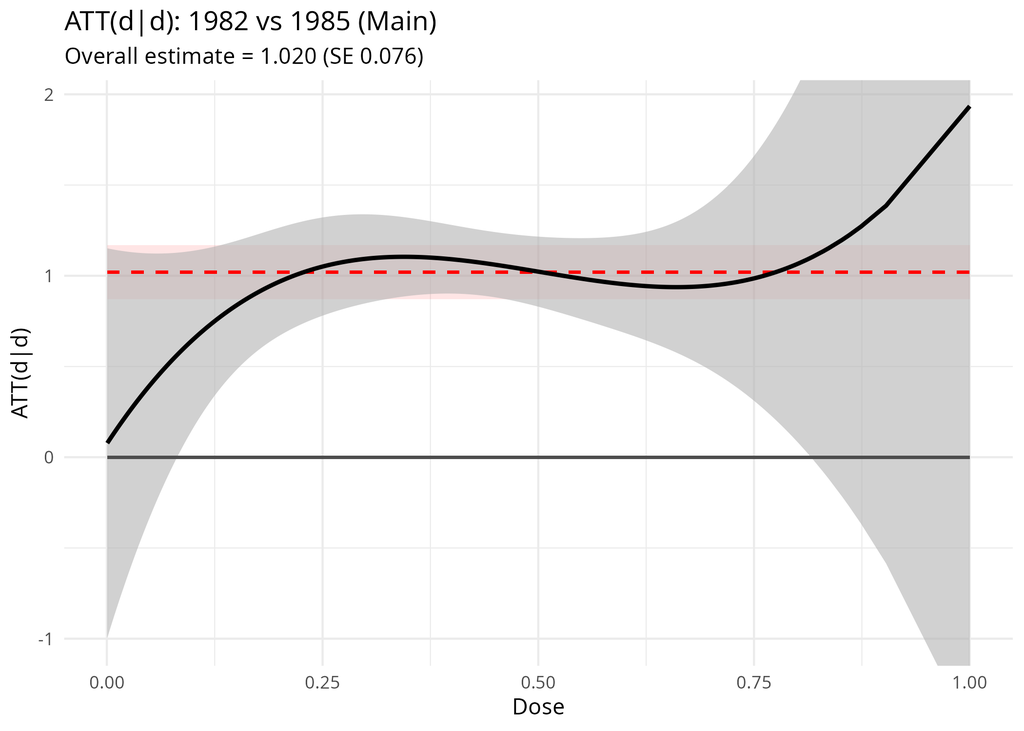

## Results: ATT(d|d)

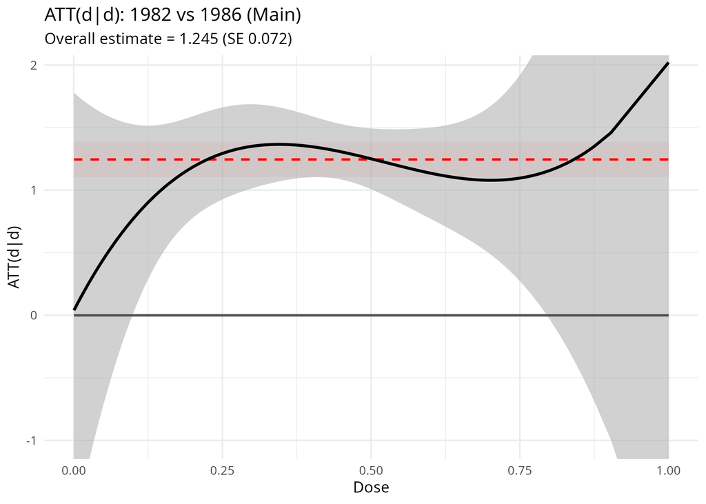

## Results: ACR(d)

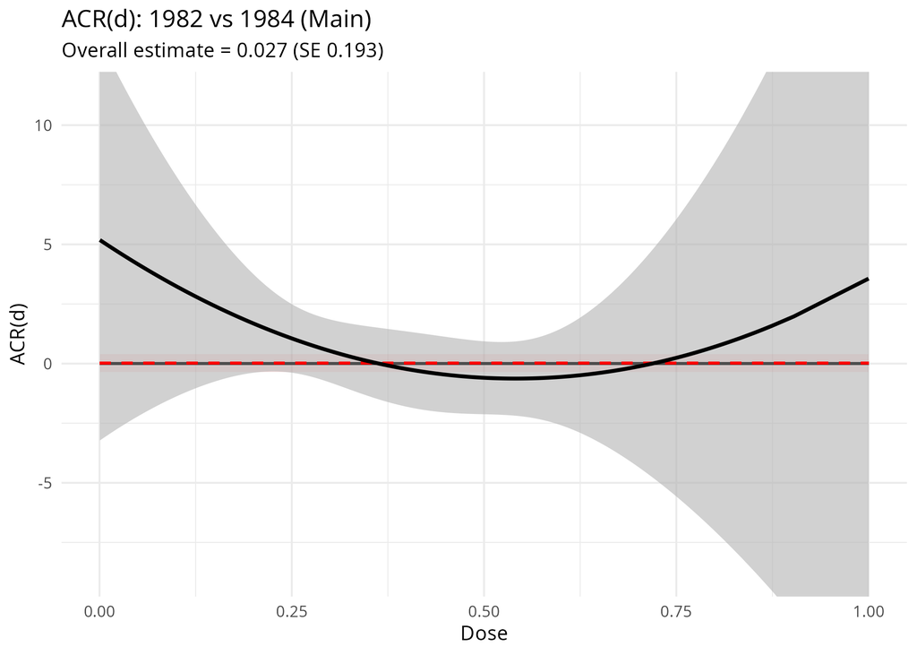

## Results: ACR(d)

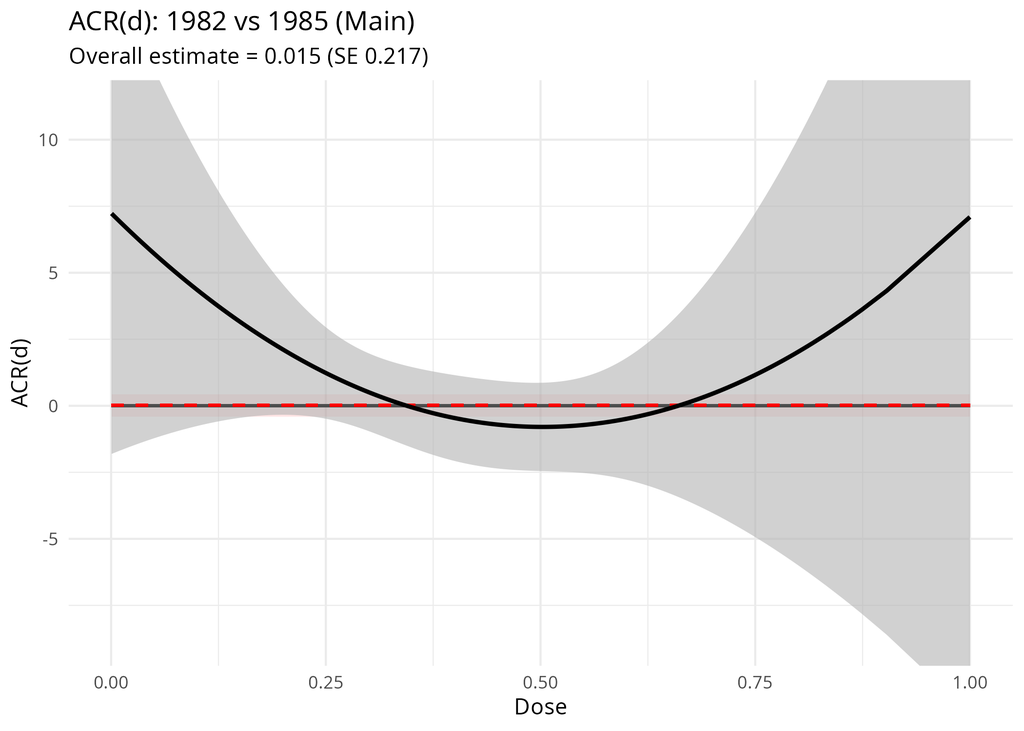

## Results: ACR(d)

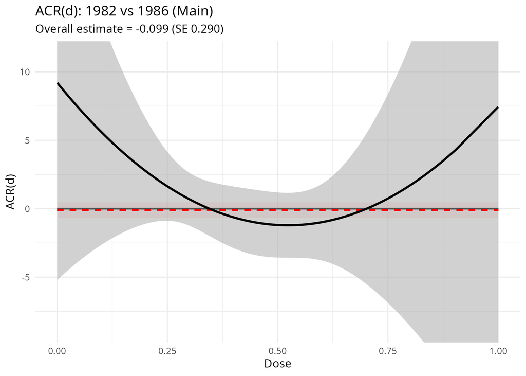

## Pre-Test: ATT(d|d)

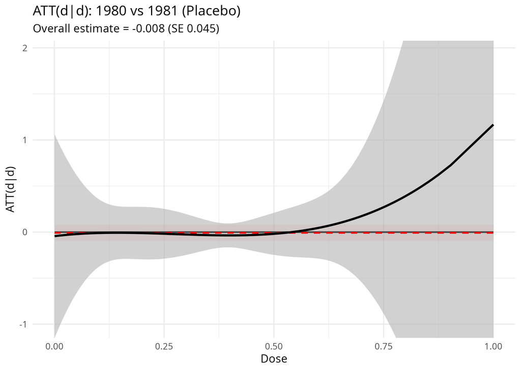

## Pre-Test: ATT(d|d)

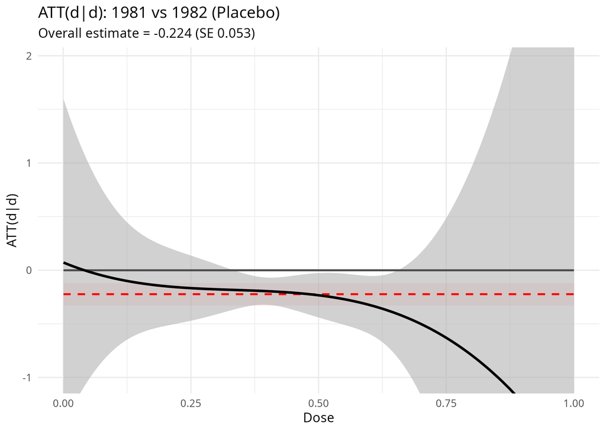

## Pre-Test: ATT(d|d)

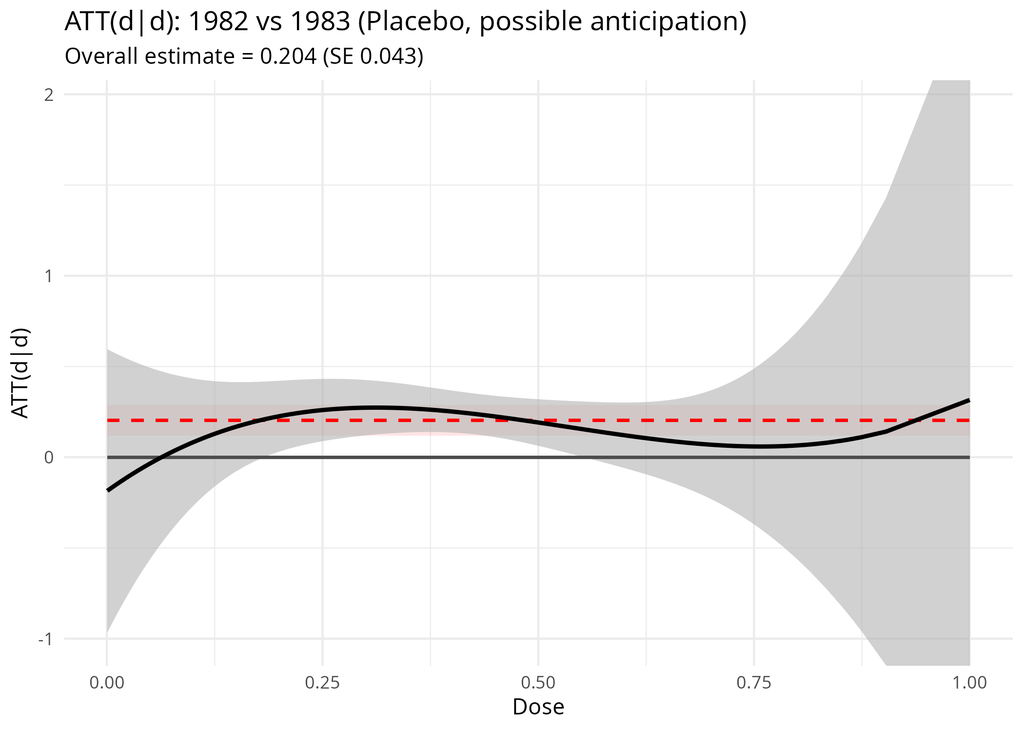

## Pre-Test: ATT(d|d)

Two of three fail — 1980-81 is close to 0, but 1981-82 ($\widehat{\ATT}=-0.22$) and 1982-83 ($\widehat{\ATT}=+0.20$) are both significant, in *opposite* directions

- 1982-83 could reflect anticipation: PPS was legislated in April 1983, months before its October 1983 effective date
- 1981-82 has no such story — both years are firmly pre-treatment. This looks like genuine year-to-year instability, not just anticipation

## Pre-Test: Same Pre-Treatment Levels

Next, we check for regions of close comparison groups

## Pre-Test: Same Pre-Treatment Levels

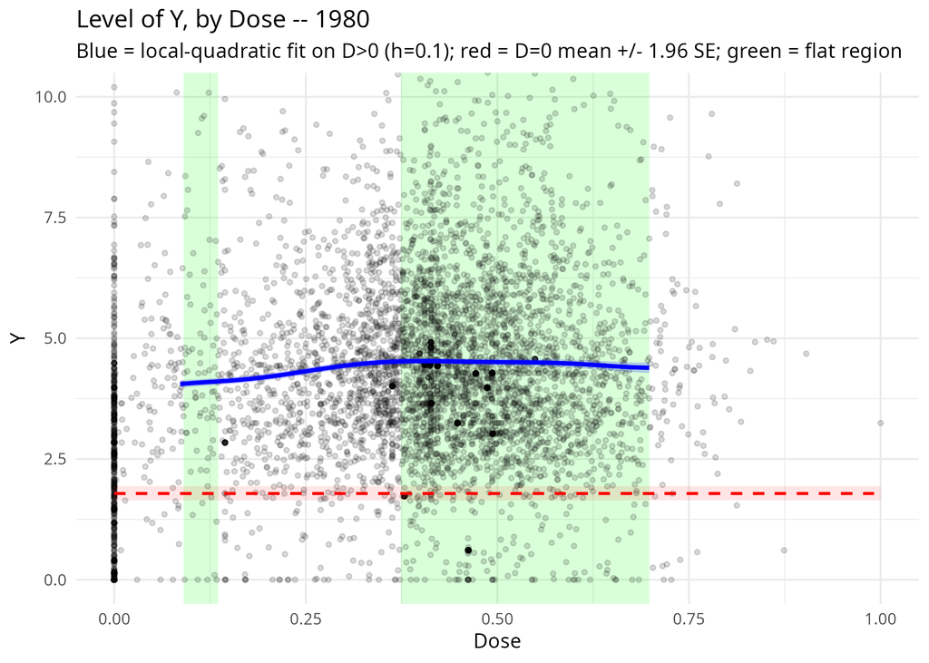

## Pre-Test: Same Pre-Treatment Levels

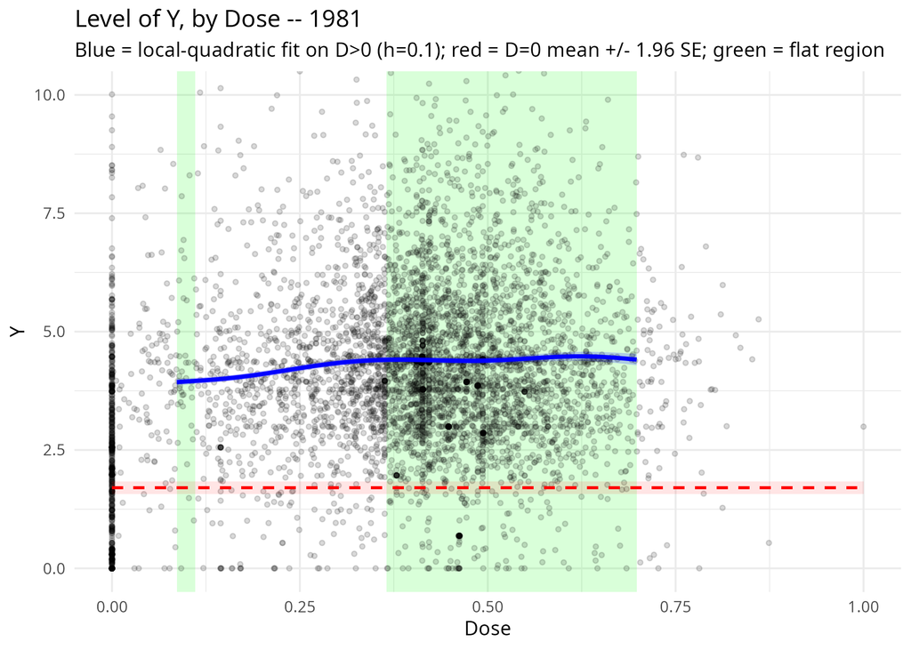

## Pre-Test: Same Pre-Treatment Levels

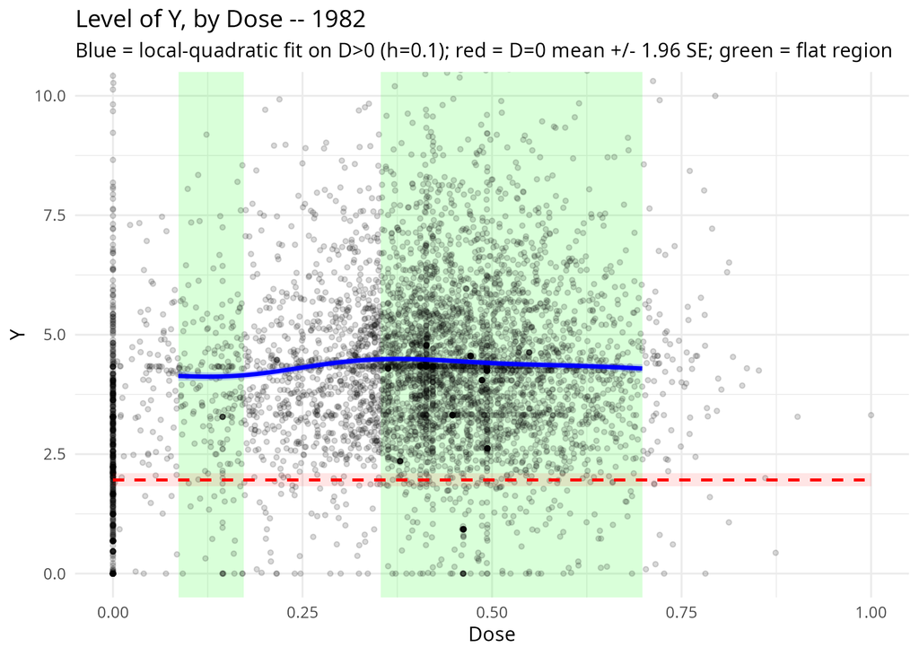

## Pre-Test: Same Pre-Treatment Levels

The flat region is remarkably stable across three separate years: roughly dose $0.35$ to $0.70$ in every one of 1980, 1981, and 1982

- This is what we’d expect if the flatness reflects a persistent hospital characteristic ($\eta_i$), not a fluke of any one year
- Use 1982’s (largest) flat region as a single canonical “close comparison group” definition, applied everywhere next

## ACR(d): Close Comparison Region

Same ACR(d) curves as before, now with the canonical region (dose $0.35$-$0.70$) highlighted, plus its density-weighted average (i.e., a local $\ACR$ in the close comparison region)

## ACR(d): Close Comparison Region

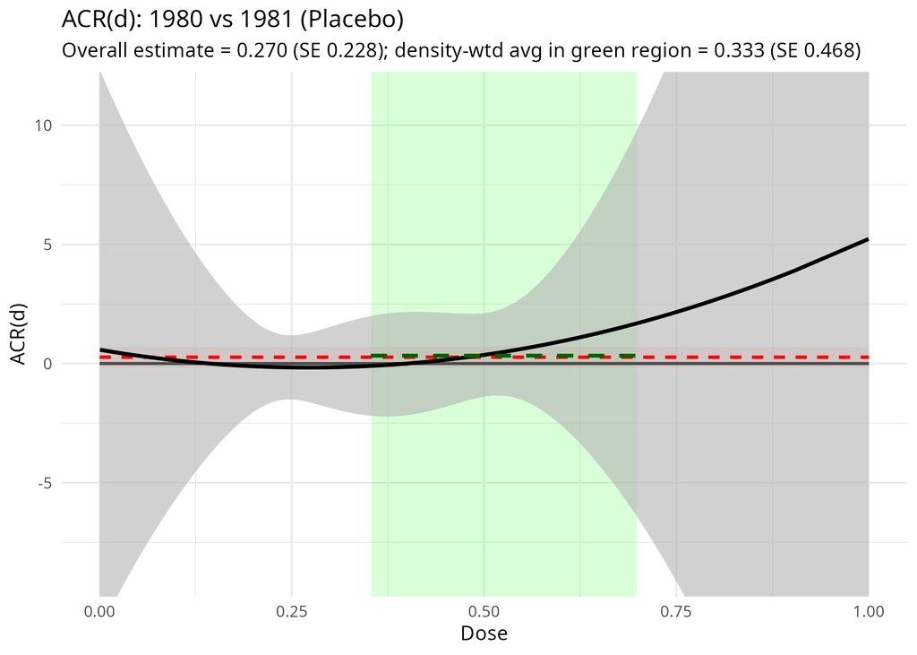

## ACR(d): Close Comparison Region

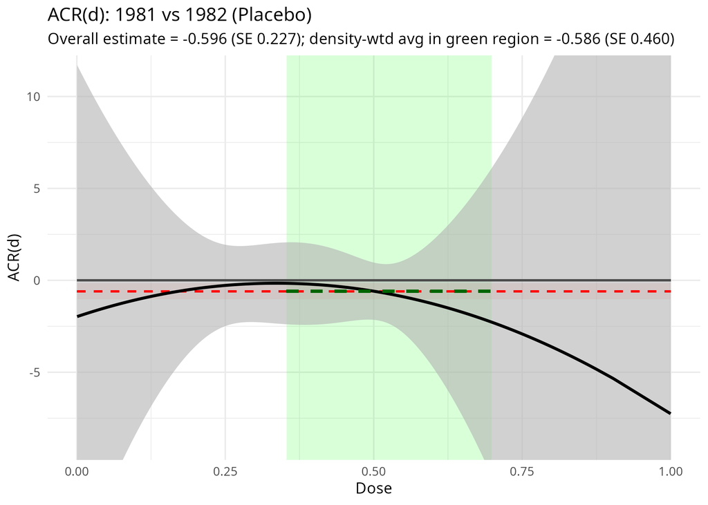

## ACR(d): Close Comparison Region

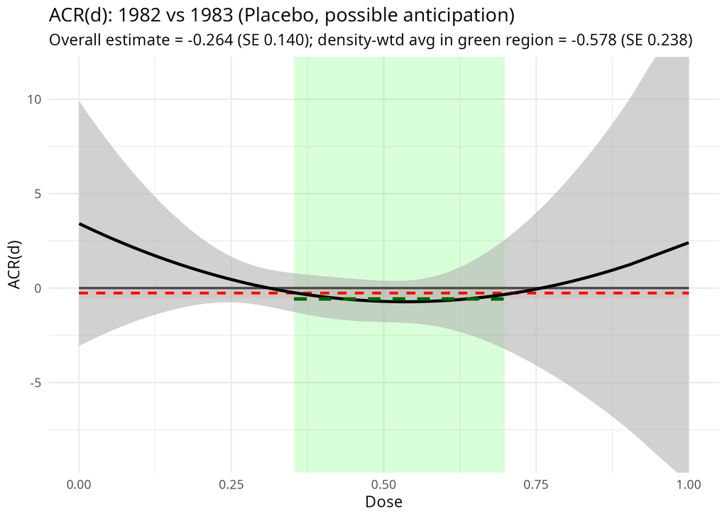

## ACR(d): Close Comparison Region

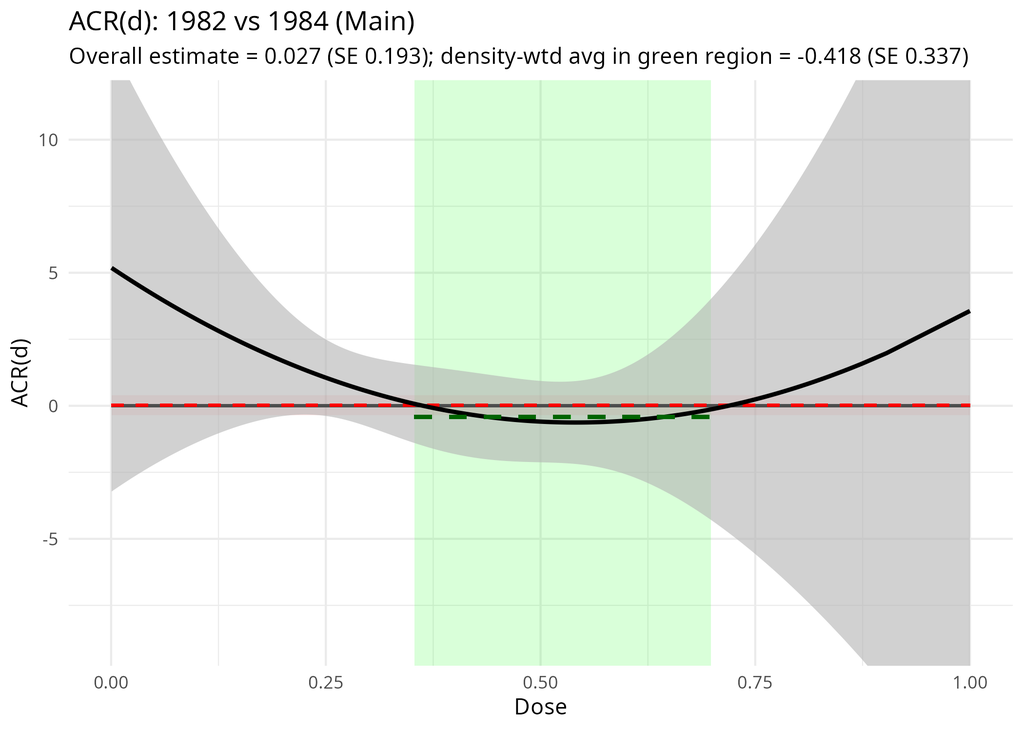

## ACR(d): Close Comparison Region

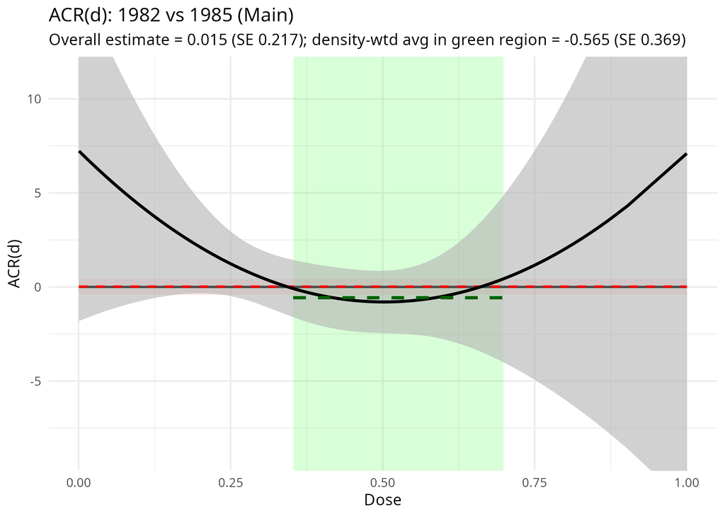

## ACR(d): Close Comparison Region

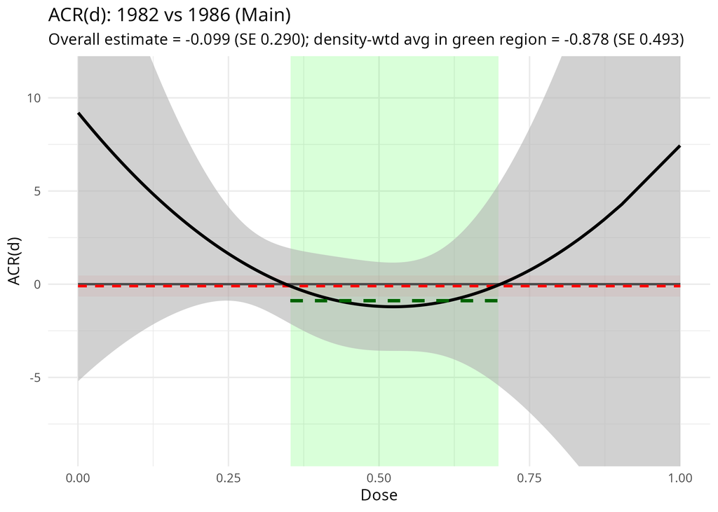

## Summary of Application

It appears that:

1. Parallel trends seems to be violated in pre-treatment periods
2. Checking the levels of pre-treatment outcomes as a function of the dose suggested that there were pockets of no selection
3. Cross-dose comparisons are more likely to deliver causal effects in those pockets (i.e., a local version of strong parallel trends)
4. The estimates were noisy, and close to zero or slightly negative (substantially different than the positive estimates from the TWFE regression). They don’t provide any evidence that the Medicare policy increased capital labor ratios.

## Conclusion

Using pre-treatment periods to assess the plausibility of strong parallel trends is challenging because only untreated potential outcomes are observed in those periods.

However, the levels of outcomes in pre-treatment periods across different dose groups provides evidence about difference in the time-invariant unobservables driving their outcomes.

- If differences in observed pre-treatment levels of outcomes are small, it suggests that differences in unobservables are small too.
- If differences in unobservables are small, then strong parallel trends is more plausible, and cross-dose comparisons of trends in outcomes can be interpreted as approximately causal in those regions.

# Appendix

## References

Acemoglu, Daron, and Amy Finkelstein. 2008. “Input and Technology Choices in Regulated Industries: Evidence from the Health Care Sector.” *Journal of Political Economy* 116 (5): 837–80.

Angrist, Joshua D, and Alan B Krueger. 1999. “Empirical Strategies in Labor Economics.” In *Handbook of Labor Economics*, 3:1277–1366. Elsevier.

Ashenfelter, Orley, and David Card. 1985. “Using the Longitudinal Structure of Earnings to Estimate the Effect of Training Programs.” *The Review of Economics and Statistics* 67 (4): 648–60.

Callaway, Brantly, Derek Dyal, Pedro HC Sant’Anna, and Emmanuel S Tsyawo. 2025. “Beyond Parallel Trends: An Identification-Strategy-Robust Approach to Causal Inference with Panel Data.”

Ghanem, Dalia, Pedro H. C. Sant’Anna, and Kaspar Wüthrich. 2024. “Selection and Parallel Trends.”

Hirano, Keisuke, and Guido W Imbens. 2004. “The Propensity Score with Continuous Treatments.” *Applied Bayesian Modeling and Causal Inference from Incomplete-Data Perspectives* 226164: 73–84.

Marx, Philip, Elie Tamer, and Xun Tang. 2025. “Heterogeneous Treatment Effects via Linear Dynamic Panel Data Models.”